# 2019年認知心理学会大会前日 ベーシック＆フロンティアセミナー

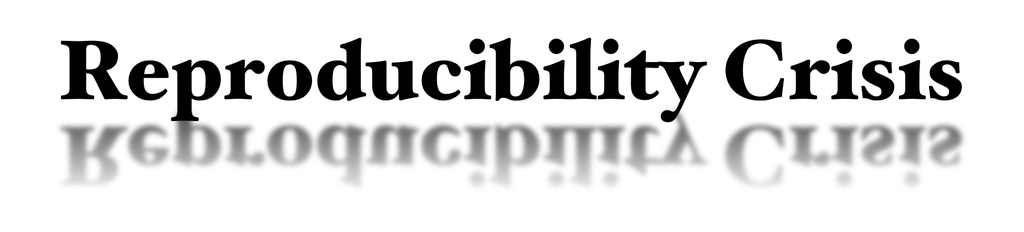

### 日本認知心理学会第17回大会 ベーシック＆フロンティアセミナー企画

# 認知心理学研究のための再現可能性のすゝめ 〜プレレジからデータ解析そしてオープンサイエンスまで〜

実習形式のチュートリアルを行いますので、**パソコンの持ち込みを推奨します**。必要なソフトウェアやデータフィアルをインストール、ダウンロードした上で、ノートパソコンの持ち込みを推奨します。

## インストール・セットアップについて

「其ノ弐 再現可能なデータ解析のすゝめ」では実習形式のチュートリアルを行う予定です。

- R https://cran.r-project.org/
- RStudio https://www.rstudio.com/products/rstudio/download/

をダウンロード、インストールの上、RStudioを起動して、以下のコマンドで必要なパッケージをインストールしていただき、下の2つのzipファイルをダウンロードしておいてもらえると、滞り無く進行できます。

```
install.packages("rprojroot")
install.packages("tidyverse")
```

- sample_project_before.zip
- sample_project_after.zip

なお、動作テストは

```
RStuido Version 1.2.1335
R version 3.5.3 (2019-03-11)
```

で行っていますが、これ以外のバージョンでも動くと思います。